# Introduction to Computer Vision: Plant Seedlings Classification

## Problem Statement

### Context

In recent times, the field of agriculture has been in urgent need of modernizing, since the amount of manual work people need to put in to check if plants are growing correctly is still highly extensive. Despite several advances in agricultural technology, people working in the agricultural industry still need to have the ability to sort and recognize different plants and weeds, which takes a lot of time and effort in the long term. The potential is ripe for this trillion-dollar industry to be greatly impacted by technological innovations that cut down on the requirement for manual labor, and this is where Artificial Intelligence can actually benefit the workers in this field, as **the time and energy required to identify plant seedlings will be greatly shortened by the use of AI and Deep Learning.** The ability to do so far more efficiently and even more effectively than experienced manual labor, could lead to better crop yields, the freeing up of human inolvement for higher-order agricultural decision making, and in the long term will result in more sustainable environmental practices in agriculture as well.

### Objective

The aim of this project is to Build a Convolutional Neural Network to classify plant seedlings into their respective categories.

### **Data Dictionary**

The Aarhus University Signal Processing group, in collaboration with the University of Southern Denmark, has recently released a dataset containing **images of unique plants belonging to 12 different species.**

- The dataset can be download from Olympus.
- The data file names are:
  - images.npy
  - Labels.csv
- Due to the large volume of data, the images were converted to the images.npy file and the labels are also put into Labels.csv, so that you can work on the data/project seamlessly without having to worry about the high data volume.
- The goal of the project is to create a classifier capable of determining a plant's species from an image.

**List of Species**

- Black-grass
- Charlock
- Cleavers
- Common Chickweed
- Common Wheat
- Fat Hen
- Loose Silky-bent
- Maize
- Scentless Mayweed
- Shepherds Purse
- Small-flowered Cranesbill
- Sugar beet

### **Note: Please use GPU runtime on Google Colab to execute the code faster.**

**General Note:** Code blocks from previous and current notebooks of material taught from in Mentored Learning Sessions and additional case studies may be used in this project notebook

## **Importing necessary libraries**

```python
# Installing the libraries with the specified version.
# uncomment and run the following line if Google Colab is being used
!pip install tensorflow==2.15.0 scikit-learn==1.2.2 seaborn==0.13.1 matplotlib==3.7.1 numpy==1.25.2 pandas==1.5.3 opencv-python==4.8.0.76 -q --user
```

**Note**: *After running the above cell, kindly restart the notebook kernel and run all cells sequentially from the start again.*

```python
import os
import numpy as np                                                                               # Importing numpy for Matrix Operations
import pandas as pd                                                                              # Importing pandas to read CSV files
import matplotlib.pyplot as plt                                                                  # Importting matplotlib for Plotting and visualizing images
import math                                                                                      # Importing math module to perform mathematical operations
import cv2                                                                                       # Importing openCV for image processing
import seaborn as sns                                                                            # Importing seaborn to plot graphs


# Tensorflow modules
import tensorflow as tf
from tensorflow.keras.preprocessing.image import ImageDataGenerator                              # Importing the ImageDataGenerator for data augmentation
from tensorflow.keras.models import Sequential                                                   # Importing the sequential module to define a sequential model
from tensorflow.keras.layers import Dense,Dropout,Flatten,Conv2D,MaxPooling2D,BatchNormalization # Defining all the layers to build our CNN Model
from tensorflow.keras.optimizers import Adam,SGD                                                 # Importing the optimizers which can be used in our model
from tensorflow.keras.callbacks import EarlyStopping
from sklearn import metrics
from sklearn import preprocessing                                                                # Importing the preprocessing module to preprocess the data
from sklearn.model_selection import train_test_split                                             # Importing train_test_split function to split the data into train and test
from sklearn.metrics import confusion_matrix                                                     # Importing confusion_matrix to plot the confusion matrix
from sklearn.preprocessing import LabelBinarizer
# Display images using OpenCV
from google.colab.patches import cv2_imshow                                                      # Importing cv2_imshow from google.patches to display images
from sklearn.model_selection import train_test_split
from tensorflow.keras import backend
from keras.callbacks import ReduceLROnPlateau
import random
from tensorflow.keras.models import Model
from keras.applications.vgg16 import VGG16
# Ignore warnings
import warnings
warnings.filterwarnings('ignore')
```

## **Loading the dataset**

```python
# Uncomment and run the below code if you are using google colab
from google.colab import drive
drive.mount('/content/drive')
```

```python
# Load the image file of dataset
file_path1 = '/content/drive/My Drive/ColabNotebooks/Plant_images.npy'
images = np.load(file_path1)

# Load the labels file of dataset
file_path2 = '/content/drive/My Drive/ColabNotebooks/Plant_Labels.csv'
labels = pd.read_csv(file_path2)
```

## **Data Overview**

### Understand the shape of the dataset

```python
#Print the shape of the datasets for images and labels
print(images.shape)
print(labels.shape)
```

```
(4750, 128, 128, 3)
(4750, 1)
```

## **Exploratory Data Analysis**

- EDA is an important part of any project involving data.
- It is important to investigate and understand the data better before building a model with it.
- A few questions have been mentioned below which will help you understand the data better.
- A thorough analysis of the data, in addition to the questions mentioned below, should be done.
1. How are these different category plant images different from each other?
2. Is the dataset provided an imbalance? (Check with using bar plots)

```python
def plot_images(images,labels):
  num_classes=12                                                                  # Number of Classes
  categories=np.unique(labels)
  keys=dict(labels['Label'])                                                      # Obtaing the unique classes from y_train
  rows = 3                                                                        # Defining number of rows=3
  cols = 4                                                                        # Defining number of columns=4
  fig = plt.figure(figsize=(10, 8))                                               # Defining the figure size to 10x8
  for i in range(cols):
      for j in range(rows):
          random_index = np.random.randint(0, len(labels))                        # Generating random indices from the data and plotting the images
          ax = fig.add_subplot(rows, cols, i * rows + j + 1)                      # Adding subplots with 3 rows and 4 columns
          ax.imshow(images[random_index, :])                                      # Plotting the image
          ax.set_title(keys[random_index])
  plt.show()
```

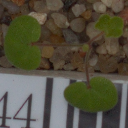

```python
#Plot Random Image at Index 5 using OpenCV
cv2_imshow(images[12])
```

[figure not shown]

```python
#Plot images from the datasets using Defined Function above
plot_images(images, labels)
```

**Observations**

- The plants images are different from each other based on:
- size (relatively to the measurement instruement in the image for some plants)
- clarity/resolution
- position of both the plant and measurement tool in the frame (center, right, left, top, bottom)
- shape (shape of leaves, stem shape, and number of leaves)
- background (more or less granular soil, shape, color)

### Checking the Distribution and any Data Imbalances of the Target Variable

```
Label
Loose Silky-bent             654
Common Chickweed             611
Scentless Mayweed            516
Small-flowered Cranesbill    496
Fat Hen                      475
Charlock                     390
Sugar beet                   385
Cleavers                     287
Black-grass                  263
Shepherds Purse              231
Common wheat                 221
Maize                        221
Name: count, dtype: int64
```

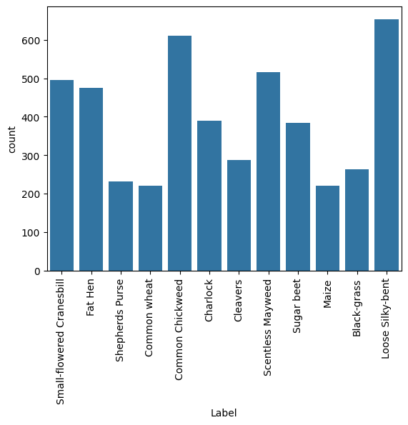

```python
#Create Plot of Counts per Plant Class
sns.countplot(x=labels['Label'])
plt.xticks(rotation='vertical')
print(labels['Label'].value_counts())
```

**Observations**

- As can be seen above the dataset is relatively Imbalanced
- Plants such as Shaprards Purse, Common Wheat, Maize, and Black-grass have counts of 200-250
- While Small-flowered Cranesbill, Fat-Hen, Common Chickweed, Scentless Mayweed, and Loose Silky Bent have counts of ~480 to ~660.

**Answers to Questions for EDA:**

1. The plants images are different from each other based on: size (relatively to the measurement instruement in the image for some plants) clarity/resolution position of both the plant and measurement tool in the frame (center, right, left, top, bottom) shape (shape of leaves, stem shape, and number of leaves) background (more or less granular soil, shape, color)
2. As can be seen above the dataset is relatively Imbalanced Plants such as Shaprards Purse, Common Wheat, Maize, and Black-grass have counts of 200-250 While Small-flowered Cranesbill, Fat-Hen, Common Chickweed, Scentless Mayweed, and Loose Silky Bent have counts of ~480 to ~680.

## **Data Pre-Processing**

### Convert the BGR images to RGB images.

```python
# Converting the images from BGR to RGB using cvtColor function of OpenCV
for i in range(len(images)):
  images[i] = cv2.cvtColor(images[i], cv2.COLOR_BGR2RGB)
```

### Resize the images

As the size of the images is large, it may be computationally expensive to train on these larger images; therefore, it is preferable to reduce the image size from 128 to 64.

```python
images_decreased=[]
height = 64
width =  64
dimensions = (width, height)
for i in range(len(images)):
  images_decreased.append( cv2.resize(images[i], dimensions, interpolation=cv2.INTER_LINEAR))
```

Image Comparison

Image Before Resizing

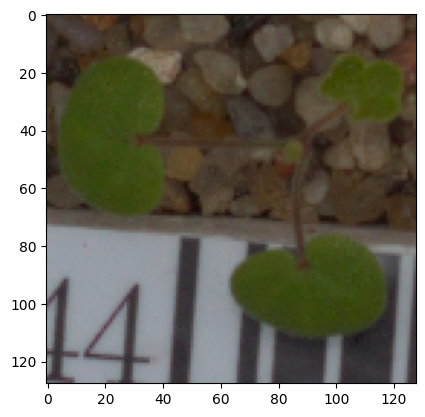

```python
plt.imshow(images[12])
```

Image After Resizing

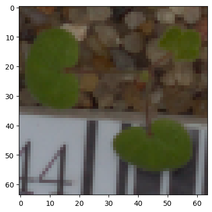

```python
plt.imshow(images_decreased[12])
```

**Observations:**

- The image is highly pixelated/noisy as a result of the resizing due to getting the image to refit within the smaller frame size, yet maintain the key features to make it identifiable

**Visualizing images using Gaussian Blur**

```python
# Applying Gaussian Blur to denoise the images
images_gb=[]
for i in range(len(images)):
  # gb[i] = cv2.cvtColor(images[i], cv2.COLOR_BGR2RGB)
  images_gb.append(cv2.GaussianBlur(images[i], ksize =(3,3),sigmaX =  0))
```

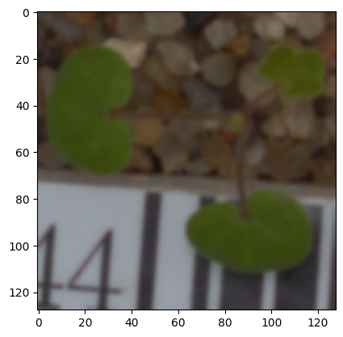

```python
plt.imshow(images_gb[12])
```

**Observations:**

- Although blurry, the image is now less pixelated/noisy. However, it seems that there are not any key features/information present allowing for easier identification/categorization of the images.

### Data Preparation for Modeling

- Before you proceed to build a model, you need to split the data into train, test, and validation to be able to evaluate the model that you build on the train data
- You'll have to encode categorical features and scale the pixel values.
- You will build a model using the train data and then check its performance

**Split the dataset**

- As we have less images in our dataset relatively (just under ~5000 images across 12 classes), we will only use 10% of our data for testing, 10% of our data for validation and 80% of our data for training.
- Data will also be stratified using the labels dataframe
- Random state will be set at 13 throughout

```python
# Split the Data into Train, Temp, Val, and Test
X_temp, X_test, y_temp, y_test = train_test_split(np.array(images_decreased),labels, test_size=0.1, random_state=13,stratify=labels)
X_train, X_val, y_train, y_val = train_test_split(X_temp,y_temp, test_size=0.1111, random_state=13,stratify=y_temp)
```

```python
# Check the shape of train, validation and test data
print(X_train.shape,y_train.shape)
print(X_val.shape,y_val.shape)
print(X_test.shape,y_test.shape)
```

```
(3800, 64, 64, 3) (3800, 1)
(475, 64, 64, 3) (475, 1)
(475, 64, 64, 3) (475, 1)
```

### Encode the target labels

Making the data compatible:

```python
# Convert labels from names to one hot vectors.
# We have already used encoding methods like onehotencoder and labelencoder earlier so now we will be using a new encoding method called labelBinarizer.
# Labelbinarizer works similar to onehotencoder

enc = LabelBinarizer()
y_train_encoded = enc.fit_transform(y_train)
y_val_encoded=enc.transform(y_val)
y_test_encoded=enc.transform(y_test)
```

```python
#Print the Shapes of the encoded one hot vectors
print(y_train_encoded.shape)
print(y_val_encoded.shape)
print(y_test_encoded.shape)
```

```
(3800, 12)
(475, 12)
(475, 12)
```

### Data Normalization

Since the image pixel values range from 0-255, our method of normalization here will be scaling - we shall divide all the pixel values by 255 to standardize the images to have values between 0-1.

```python
# Normalize the image pixels of train, test and validation data
X_train_normalized = X_train.astype('float32')/255.0
X_val_normalized = X_val.astype('float32')/255.0
X_test_normalized = X_test.astype('float32')/255.0
```

## Model Building

Let's create a CNN model sequentially, where we will be adding the layers one after another.

First, we need to clear the previous model's history from the session even if a single model can run multiple times on the same data.

In Keras, we need a special command to clear the model's history, otherwise the previous model history remains in the backend.

Also, let's fix the seed again after clearing the backend.

Let's set the seed for random number generators in Numpy, the Random library in Python, and in TensorFlow to be able to reproduce the same results every time we run the code blocks.

```python
# Clearing backend
backend.clear_session()

# Fixing the seed for random number generators
np.random.seed(13)
random.seed(13)
tf.random.set_seed(13)
```

Now, let's build a CNN Model with the following 2 main parts -

The Feature Extraction layers which are comprised of convolutional and pooling layers. The Fully Connected classification layers for prediction.

- Filters: 64- Number of filters in the first hidden layer.This is also called as Kernel
- Kernel_Size: The kernel size here refers to the widthxheight of the filter mask. The kernel_size must be an odd integer as well. Typical values for kernel_size include: (1, 1) , (3, 3) , (5, 5) , (7, 7)
- Padding: The padding type is called SAME because the output size is the same as the input size(when stride=1). Using 'SAME' ensures that the filter is applied to all the elements of the input. Normally, padding is set to "SAME" while training the model. Output size is mathematically convenient for further computation.
- MaxPool2D: Max Pooling is a pooling operation that calculates the maximum value for patches of a feature map, and uses it to create a downsampled (pooled) feature map. It is usually used after a convolutional layer.
- Flatten: Flattening is converting the data into a 1-dimensional array for giving them as input to the next layer. We flatten the output of the convolutional layers to create a single long feature vector. And it is connected to the final classification model, which is called a fully-connected layer.

```python
# Intializing a sequential model
modelA = Sequential()

# Add the first conv layer with 128 filters and kernel size 3x3 , padding 'same' provides the output size same as the input size
# Input_shape denotes input image dimension of images
modelA.add(Conv2D(64, (3, 3), activation='relu', padding="same", input_shape=(64, 64, 3)))

# Add the max pooling to reduce the size of output of first conv layer
modelA.add(MaxPooling2D((2, 2), padding = 'same'))

# Create two similar convolution and max-pooling layers activation = relu
#Step down the number of filters from 64 to 32 as the only difference to focus on key feature abstraction and reuce chances of overfitting
modelA.add(Conv2D(64, (3, 3), activation='relu', padding="same"))
modelA.add(MaxPooling2D((2, 2), padding = 'same'))
modelA.add(Conv2D(32, (3, 3), activation='relu', padding="same"))
modelA.add(MaxPooling2D((2, 2), padding = 'same'))

# Flatten the output of the conv layer after max pooling to make it ready for creating dense connections
modelA.add(Flatten())

# Add a fully connected dense layer with 16 neurons followed by dropout proportion of 0.3
modelA.add(Dense(16, activation='relu'))
modelA.add(Dropout(0.3))
# Add the output layer with 12 neurons, since there are 12 output classes and activation functions as softmax since this is a multi-class classification problem
modelA.add(Dense(12, activation='softmax'))

# Use the Adam Optimizer since it is the best optimizer to use on average
opt=Adam()
# Compile the model using categorical cross entropyy as it is the best loss function for multi-class classification problems
modelA.compile(optimizer=opt, loss='categorical_crossentropy', metrics=['accuracy'])

# Generate the summary of the model
modelA.summary()
```

```
Model: "sequential"
```

```
┏━━━━━━━━━━━━━━━━━━━━━━━━━━━━━━━━━━━━━━┳━━━━━━━━━━━━━━━━━━━━━━━━━━━━━┳━━━━━━━━━━━━━━━━━┓
┃ Layer (type)                         ┃ Output Shape                ┃         Param # ┃
┡━━━━━━━━━━━━━━━━━━━━━━━━━━━━━━━━━━━━━━╇━━━━━━━━━━━━━━━━━━━━━━━━━━━━━╇━━━━━━━━━━━━━━━━━┩
│ conv2d (Conv2D)                      │ (None, 64, 64, 64)          │           1,792 │
├──────────────────────────────────────┼─────────────────────────────┼─────────────────┤
│ max_pooling2d (MaxPooling2D)         │ (None, 32, 32, 64)          │               0 │
├──────────────────────────────────────┼─────────────────────────────┼─────────────────┤
│ conv2d_1 (Conv2D)                    │ (None, 32, 32, 64)          │          36,928 │
├──────────────────────────────────────┼─────────────────────────────┼─────────────────┤
│ max_pooling2d_1 (MaxPooling2D)       │ (None, 16, 16, 64)          │               0 │
├──────────────────────────────────────┼─────────────────────────────┼─────────────────┤
│ conv2d_2 (Conv2D)                    │ (None, 16, 16, 32)          │          18,464 │
├──────────────────────────────────────┼─────────────────────────────┼─────────────────┤
│ max_pooling2d_2 (MaxPooling2D)       │ (None, 8, 8, 32)            │               0 │
├──────────────────────────────────────┼─────────────────────────────┼─────────────────┤
│ flatten (Flatten)                    │ (None, 2048)                │               0 │
├──────────────────────────────────────┼─────────────────────────────┼─────────────────┤
│ dense (Dense)                        │ (None, 16)                  │          32,784 │
├──────────────────────────────────────┼─────────────────────────────┼─────────────────┤
│ dropout (Dropout)                    │ (None, 16)                  │               0 │
├──────────────────────────────────────┼─────────────────────────────┼─────────────────┤
│ dense_1 (Dense)                      │ (None, 12)                  │             204 │
└──────────────────────────────────────┴─────────────────────────────┴─────────────────┘
```

```
 Total params: 90,172 (352.23 KB)
```

```
 Trainable params: 90,172 (352.23 KB)
```

```
 Non-trainable params: 0 (0.00 B)
```

Observations:

- Total Parameters is 90,172 and all parameters are trainable as well

**Fitting the model on the train data**

```python
# Fit the model on train data with batch_size=64 and epochs=30
epochs = 30
batch_size = 64

# Fit the model on train data and also using the validation data for validation
history_A = modelA.fit(
            X_train_normalized,y_train_encoded,
            epochs=epochs,
            batch_size=batch_size,
            validation_data=(X_val_normalized,y_val_encoded),
            verbose=2
)
```

```
60/60 - 12s - 197ms/step - accuracy: 0.1284 - loss: 2.4612 - val_accuracy: 0.1284 - val_loss: 2.4308
60/60 - 11s - 180ms/step - accuracy: 0.1613 - loss: 2.4325 - val_accuracy: 0.2632 - val_loss: 2.3591
60/60 - 1s - 17ms/step - accuracy: 0.2134 - loss: 2.3565 - val_accuracy: 0.2716 - val_loss: 2.2721
60/60 - 1s - 11ms/step - accuracy: 0.2347 - loss: 2.2724 - val_accuracy: 0.3305 - val_loss: 2.1151
60/60 - 1s - 11ms/step - accuracy: 0.2695 - loss: 2.1835 - val_accuracy: 0.3516 - val_loss: 1.9921
60/60 - 1s - 11ms/step - accuracy: 0.3042 - loss: 2.0617 - val_accuracy: 0.3874 - val_loss: 1.8357
60/60 - 1s - 10ms/step - accuracy: 0.3226 - loss: 1.9559 - val_accuracy: 0.4063 - val_loss: 1.7718
60/60 - 1s - 11ms/step - accuracy: 0.3329 - loss: 1.8920 - val_accuracy: 0.4147 - val_loss: 1.6983
60/60 - 1s - 21ms/step - accuracy: 0.3661 - loss: 1.8050 - val_accuracy: 0.4505 - val_loss: 1.5819
60/60 - 1s - 21ms/step - accuracy: 0.3832 - loss: 1.7605 - val_accuracy: 0.4905 - val_loss: 1.5734
60/60 - 1s - 21ms/step - accuracy: 0.4118 - loss: 1.7115 - val_accuracy: 0.5347 - val_loss: 1.4562
60/60 - 1s - 21ms/step - accuracy: 0.4279 - loss: 1.6550 - val_accuracy: 0.5242 - val_loss: 1.4510
60/60 - 1s - 22ms/step - accuracy: 0.4303 - loss: 1.6079 - val_accuracy: 0.5600 - val_loss: 1.3608
60/60 - 1s - 22ms/step - accuracy: 0.4395 - loss: 1.5753 - val_accuracy: 0.5537 - val_loss: 1.4181
60/60 - 1s - 12ms/step - accuracy: 0.4526 - loss: 1.5408 - val_accuracy: 0.5705 - val_loss: 1.3239
60/60 - 1s - 20ms/step - accuracy: 0.4558 - loss: 1.5290 - val_accuracy: 0.6021 - val_loss: 1.2772
60/60 - 1s - 21ms/step - accuracy: 0.4689 - loss: 1.4669 - val_accuracy: 0.5684 - val_loss: 1.3079
60/60 - 1s - 10ms/step - accuracy: 0.4766 - loss: 1.4139 - val_accuracy: 0.6063 - val_loss: 1.2193
60/60 - 1s - 11ms/step - accuracy: 0.4724 - loss: 1.4318 - val_accuracy: 0.6126 - val_loss: 1.1842
60/60 - 1s - 11ms/step - accuracy: 0.4763 - loss: 1.4148 - val_accuracy: 0.5979 - val_loss: 1.1830
60/60 - 1s - 11ms/step - accuracy: 0.4853 - loss: 1.3878 - val_accuracy: 0.6000 - val_loss: 1.2487
60/60 - 1s - 21ms/step - accuracy: 0.4816 - loss: 1.4025 - val_accuracy: 0.6021 - val_loss: 1.2593
60/60 - 1s - 11ms/step - accuracy: 0.4721 - loss: 1.4030 - val_accuracy: 0.5916 - val_loss: 1.2955
60/60 - 1s - 11ms/step - accuracy: 0.4958 - loss: 1.3420 - val_accuracy: 0.5853 - val_loss: 1.3397
60/60 - 1s - 11ms/step - accuracy: 0.5016 - loss: 1.3236 - val_accuracy: 0.6337 - val_loss: 1.1583
60/60 - 1s - 11ms/step - accuracy: 0.5163 - loss: 1.2924 - val_accuracy: 0.6611 - val_loss: 1.0805
60/60 - 1s - 11ms/step - accuracy: 0.5450 - loss: 1.2157 - val_accuracy: 0.6779 - val_loss: 1.0402
60/60 - 1s - 11ms/step - accuracy: 0.5358 - loss: 1.2247 - val_accuracy: 0.6884 - val_loss: 1.0225
60/60 - 1s - 22ms/step - accuracy: 0.5274 - loss: 1.2220 - val_accuracy: 0.6863 - val_loss: 0.9968
60/60 - 1s - 12ms/step - accuracy: 0.5553 - loss: 1.1872 - val_accuracy: 0.6947 - val_loss: 1.0001
```

**Model Evaluation**

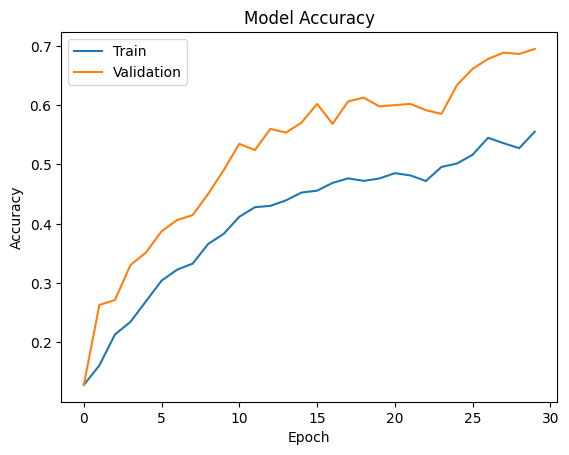

```python
#Plot the Training vs Validation Accuracy
plt.plot(history_A.history['accuracy'])
plt.plot(history_A.history['val_accuracy'])
plt.title('Model Accuracy')
plt.ylabel('Accuracy')
plt.xlabel('Epoch')
plt.legend(['Train', 'Validation'], loc='upper left')
plt.show()
```

Observations:

- Validation Accuracy is better than the training accuracy by ~14% on average it seems between the trendlines
- Max validation accuracy is ~70% compared to ~56% for training accuracy.
- These are solid initial results, but can be improved upon

**Evaluate the model on test data**

```python
# Evaluate the model on test data
accuracyA = modelA.evaluate(X_test_normalized, y_test_encoded, verbose=2)  # evaluate the model on test data
```

```
15/15 - 1s - 73ms/step - accuracy: 0.6505 - loss: 1.0782
```

Observations:

- Max Test Accuracy is ~65%.
- These are solid initial results, but can be improved upon

**Plotting the Confusion Matrix**

Generating the Predictions for the Confusion Matrix using the Test Data

```python
# Here we would get the output as probablities for each category
y_pred=modelA.predict(X_test_normalized)
# predict the output probabilities
```

```
15/15 ━━━━━━━━━━━━━━━━━━━━ 1s 29ms/step
```

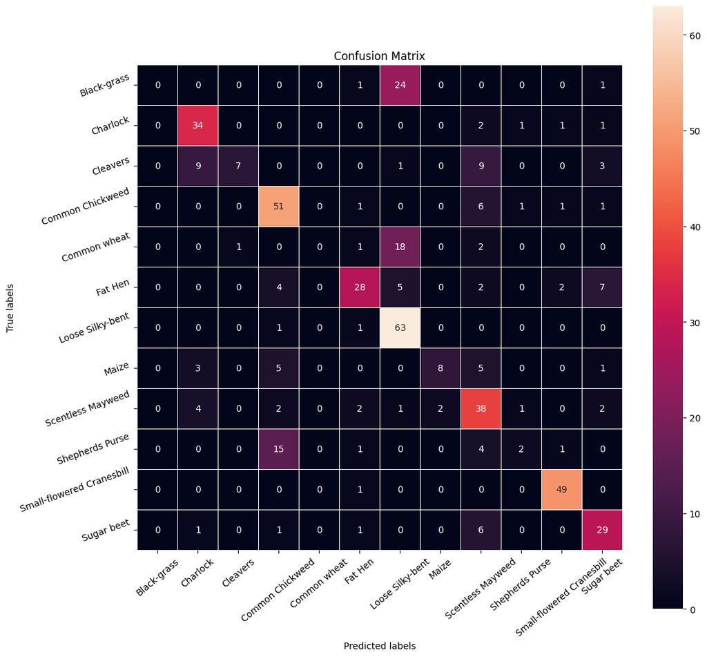

```python
# Obtaining the categorical values from y_test_encoded and y_pred
y_pred_arg=np.argmax(y_pred,axis=1)
y_test_arg=np.argmax(y_test_encoded,axis=1)

# Plotting the Confusion Matrix using confusion matrix() function which is also predefined in tensorflow module
confusion_matrix = tf.math.confusion_matrix(y_test_arg,y_pred_arg)         # plot the confusion matrix
f, ax = plt.subplots(figsize=(12, 12))
sns.heatmap(
    confusion_matrix,
    annot=True,
    linewidths=.4,
    fmt="d",
    square=True,
    ax=ax
)
# Setting the labels to both the axes
ax.set_xlabel('Predicted labels');ax.set_ylabel('True labels');
ax.set_title('Confusion Matrix');
ax.xaxis.set_ticklabels(list(enc.classes_),rotation=40)
ax.yaxis.set_ticklabels(list(enc.classes_),rotation=20)
plt.show()
```

**Generating Classification Report**

```python
# Generating the classification report
crA = metrics.classification_report(y_test_arg,y_pred_arg)     # generate the classification report
print(crA)
```

```
              precision    recall  f1-score   support

           0       0.00      0.00      0.00        26
           1       0.67      0.87      0.76        39
           2       0.88      0.24      0.38        29
           3       0.65      0.84      0.73        61
           4       0.00      0.00      0.00        22
           5       0.76      0.58      0.66        48
           6       0.56      0.97      0.71        65
           7       0.80      0.36      0.50        22
           8       0.51      0.73      0.60        52
           9       0.40      0.09      0.14        23
          10       0.91      0.98      0.94        50
          11       0.64      0.76      0.70        38

    accuracy                           0.65       475
   macro avg       0.56      0.54      0.51       475
weighted avg       0.60      0.65      0.59       475
```

## Model Performance Improvement

**Reducing the Learning Rate:**

**Hint**: Use **ReduceLRonPlateau()** function that will be used to decrease the learning rate by some factor, if the loss is not decreasing for some time. This may start decreasing the loss at a smaller learning rate. There is a possibility that the loss may still not decrease. This may lead to executing the learning rate reduction again in an attempt to achieve a lower loss.

```python
# To monitor val_accuracy and reduce learning rate if needed to optimize val accuracy
lr_reduced = ReduceLROnPlateau(monitor='val_accuracy',
                                            patience=3,
                                            verbose=1,
                                            factor=0.5,
                                            min_lr=0.00001)
```

### **Data Augmentation**

Remember, **data augmentation should not be used in the validation/test data set**.

In most of the real-world case studies, it is challenging to acquire a large number of images and then train CNNs. To overcome this problem, one approach we might consider is Data Augmentation. CNNs have the property of translational invariance, which means they can recognise an object even if its appearance shifts translationally in some way. Taking this attribute into account, we can augment the images using the techniques listed below -

1. Horizontal Flip (should be set to True/False)
2. Vertical Flip (should be set to True/False)
3. Height Shift (should be between 0 and 1)
4. Width Shift (should be between 0 and 1)
5. Rotation (should be between 0 and 180)
6. Shear (should be between 0 and 1)
7. Zoom (should be between 0 and 1) etc.

Remember, data augmentation should not be used in the validation/test data set.

```python
# Clearing backend
backend.clear_session()

# Fixing the seed for random number generators
np.random.seed(13)
random.seed(13)
tf.random.set_seed(13)
```

```python
# Set training data generation to have a rotation of 60
train_datagen = ImageDataGenerator(
                              rotation_range=60,
                              fill_mode='nearest'
                              )
```

```python
# Intializing a sequential model
modelB = Sequential()

# Add the first conv layer with 64 filters and kernel size 3x3 , padding 'same' provides the output size same as the input size
# Input_shape denotes input image dimension images
# Add max pooling to reduce the size of output of first conv layer
modelB.add(Conv2D(64, (3, 3), activation='relu', padding="same", input_shape=(64, 64, 3)))
modelB.add(MaxPooling2D((2, 2), padding = 'same'))

# Add the second conv layer with 32 filters and kernel size 3x3 , padding 'same' provides the output size same as the input size
# Input_shape denotes input image dimension images
# Add max pooling to reduce the size of output of first conv layer
# Add batch normalization to regularize the data/introduce some noise, to focus on key feature extraction
# Flatten the output of the conv layer after max pooling to make it ready for creating dense connections
modelB.add(Conv2D(32, (3, 3), activation='relu', padding="same"))
modelB.add(MaxPooling2D((2, 2), padding = 'same'))
modelB.add(BatchNormalization())
modelB.add(Flatten())

# Adding a fully connected dense layer with 16 neurons
modelB.add(Dense(16, activation='relu'))
# Add dropout with dropout_rate=0.3
modelB.add(Dropout(0.3))
# add the output layer with 12 neurons and activation functions as softmax since this is a multi-class classification problem
modelB.add(Dense(12, activation='softmax'))

# initialize Adam Optimimzer
opt= Adam()
# Compile model
modelB.compile(optimizer=opt, loss='categorical_crossentropy', metrics=['accuracy'])

# Generating the summary of the model
modelB.summary()
```

```
Model: "sequential"
```

```
┏━━━━━━━━━━━━━━━━━━━━━━━━━━━━━━━━━━━━━━┳━━━━━━━━━━━━━━━━━━━━━━━━━━━━━┳━━━━━━━━━━━━━━━━━┓
┃ Layer (type)                         ┃ Output Shape                ┃         Param # ┃
┡━━━━━━━━━━━━━━━━━━━━━━━━━━━━━━━━━━━━━━╇━━━━━━━━━━━━━━━━━━━━━━━━━━━━━╇━━━━━━━━━━━━━━━━━┩
│ conv2d (Conv2D)                      │ (None, 64, 64, 64)          │           1,792 │
├──────────────────────────────────────┼─────────────────────────────┼─────────────────┤
│ max_pooling2d (MaxPooling2D)         │ (None, 32, 32, 64)          │               0 │
├──────────────────────────────────────┼─────────────────────────────┼─────────────────┤
│ conv2d_1 (Conv2D)                    │ (None, 32, 32, 32)          │          18,464 │
├──────────────────────────────────────┼─────────────────────────────┼─────────────────┤
│ max_pooling2d_1 (MaxPooling2D)       │ (None, 16, 16, 32)          │               0 │
├──────────────────────────────────────┼─────────────────────────────┼─────────────────┤
│ batch_normalization                  │ (None, 16, 16, 32)          │             128 │
│ (BatchNormalization)                 │                             │                 │
├──────────────────────────────────────┼─────────────────────────────┼─────────────────┤
│ flatten (Flatten)                    │ (None, 8192)                │               0 │
├──────────────────────────────────────┼─────────────────────────────┼─────────────────┤
│ dense (Dense)                        │ (None, 16)                  │         131,088 │
├──────────────────────────────────────┼─────────────────────────────┼─────────────────┤
│ dropout (Dropout)                    │ (None, 16)                  │               0 │
├──────────────────────────────────────┼─────────────────────────────┼─────────────────┤
│ dense_1 (Dense)                      │ (None, 12)                  │             204 │
└──────────────────────────────────────┴─────────────────────────────┴─────────────────┘
```

```
 Total params: 151,676 (592.48 KB)
```

```
 Trainable params: 151,612 (592.23 KB)
```

```
 Non-trainable params: 64 (256.00 B)
```

Observations:

- There are 151,676 total parameters
- 151,612 are trainable and 64 are non-trainable

**Fitting the model on the train data**

```python
# Fit the model on train data with batch_size=64 and epochs=30
epochs = 30
batch_size = 64
# Fit the model on train data and also using the validation data for validation
history_B = modelB.fit(train_datagen.flow(X_train_normalized,y_train_encoded,
                                       batch_size=batch_size,seed=13,
                                       shuffle=False), #Removed epochs
                                       epochs=epochs, #Placed epochs outside flow for model.fit to use
                                       steps_per_epoch=X_train_normalized.shape[0] // batch_size,
                                       validation_data=(X_val_normalized,y_val_encoded),
                                       verbose=1,callbacks=[lr_reduced])
```

```
59/59 ━━━━━━━━━━━━━━━━━━━━ 16s 179ms/step - accuracy: 0.1192 - loss: 2.4875 - val_accuracy: 0.1747 - val_loss: 2.4344 - learning_rate: 0.0010
59/59 ━━━━━━━━━━━━━━━━━━━━ 0s 2ms/step - accuracy: 0.1562 - loss: 2.2877 - val_accuracy: 0.1389 - val_loss: 2.4354 - learning_rate: 0.0010
59/59 ━━━━━━━━━━━━━━━━━━━━ 6s 101ms/step - accuracy: 0.2926 - loss: 2.1159 - val_accuracy: 0.3347 - val_loss: 2.3403 - learning_rate: 0.0010
59/59 ━━━━━━━━━━━━━━━━━━━━ 0s 1ms/step - accuracy: 0.3594 - loss: 1.9787 - val_accuracy: 0.3242 - val_loss: 2.3350 - learning_rate: 0.0010
59/59 ━━━━━━━━━━━━━━━━━━━━ 5s 73ms/step - accuracy: 0.3552 - loss: 1.8600 - val_accuracy: 0.3853 - val_loss: 2.2622 - learning_rate: 0.0010
59/59 ━━━━━━━━━━━━━━━━━━━━ 0s 1ms/step - accuracy: 0.4375 - loss: 1.7289 - val_accuracy: 0.4021 - val_loss: 2.2415 - learning_rate: 0.0010
59/59 ━━━━━━━━━━━━━━━━━━━━ 5s 80ms/step - accuracy: 0.4221 - loss: 1.7066 - val_accuracy: 0.3516 - val_loss: 2.0378 - learning_rate: 0.0010
59/59 ━━━━━━━━━━━━━━━━━━━━ 0s 2ms/step - accuracy: 0.4531 - loss: 1.5517 - val_accuracy: 0.3453 - val_loss: 2.0235 - learning_rate: 0.0010
59/59 ━━━━━━━━━━━━━━━━━━━━ 10s 71ms/step - accuracy: 0.4546 - loss: 1.5536 - val_accuracy: 0.5789 - val_loss: 1.8318 - learning_rate: 0.0010
59/59 ━━━━━━━━━━━━━━━━━━━━ 0s 1ms/step - accuracy: 0.6094 - loss: 1.1856 - val_accuracy: 0.5768 - val_loss: 1.8266 - learning_rate: 0.0010
59/59 ━━━━━━━━━━━━━━━━━━━━ 9s 147ms/step - accuracy: 0.5134 - loss: 1.3928 - val_accuracy: 0.6105 - val_loss: 1.6141 - learning_rate: 0.0010
59/59 ━━━━━━━━━━━━━━━━━━━━ 0s 2ms/step - accuracy: 0.6250 - loss: 1.0639 - val_accuracy: 0.6274 - val_loss: 1.6249 - learning_rate: 0.0010
59/59 ━━━━━━━━━━━━━━━━━━━━ 6s 78ms/step - accuracy: 0.5353 - loss: 1.3357 - val_accuracy: 0.4947 - val_loss: 1.5928 - learning_rate: 0.0010
59/59 ━━━━━━━━━━━━━━━━━━━━ 0s 1ms/step - accuracy: 0.5625 - loss: 1.4331 - val_accuracy: 0.4737 - val_loss: 1.6462 - learning_rate: 0.0010
59/59 ━━━━━━━━━━━━━━━━━━━━ 9s 71ms/step - accuracy: 0.5570 - loss: 1.2644 - val_accuracy: 0.6779 - val_loss: 1.2848 - learning_rate: 0.0010
59/59 ━━━━━━━━━━━━━━━━━━━━ 0s 1ms/step - accuracy: 0.5625 - loss: 1.3192 - val_accuracy: 0.6716 - val_loss: 1.2550 - learning_rate: 0.0010
59/59 ━━━━━━━━━━━━━━━━━━━━ 5s 75ms/step - accuracy: 0.5778 - loss: 1.1968 - val_accuracy: 0.7074 - val_loss: 1.0494 - learning_rate: 0.0010
59/59 ━━━━━━━━━━━━━━━━━━━━ 0s 2ms/step - accuracy: 0.6406 - loss: 1.2010 - val_accuracy: 0.6989 - val_loss: 1.0603 - learning_rate: 0.0010
59/59 ━━━━━━━━━━━━━━━━━━━━ 6s 92ms/step - accuracy: 0.6092 - loss: 1.0956 - val_accuracy: 0.6484 - val_loss: 1.1523 - learning_rate: 0.0010
 1/59 ━━━━━━━━━━━━━━━━━━━━ 0s 14ms/step - accuracy: 0.5938 - loss: 1.1497
Epoch 20: ReduceLROnPlateau reducing learning rate to 0.0005000000237487257.
59/59 ━━━━━━━━━━━━━━━━━━━━ 0s 1ms/step - accuracy: 0.5938 - loss: 1.1497 - val_accuracy: 0.6147 - val_loss: 1.2443 - learning_rate: 0.0010
59/59 ━━━━━━━━━━━━━━━━━━━━ 9s 84ms/step - accuracy: 0.6330 - loss: 1.0252 - val_accuracy: 0.6758 - val_loss: 1.0295 - learning_rate: 5.0000e-04
59/59 ━━━━━━━━━━━━━━━━━━━━ 0s 2ms/step - accuracy: 0.6562 - loss: 1.0022 - val_accuracy: 0.6758 - val_loss: 1.0245 - learning_rate: 5.0000e-04
59/59 ━━━━━━━━━━━━━━━━━━━━ 9s 72ms/step - accuracy: 0.6557 - loss: 0.9746 - val_accuracy: 0.7495 - val_loss: 0.7955 - learning_rate: 5.0000e-04
59/59 ━━━━━━━━━━━━━━━━━━━━ 0s 1ms/step - accuracy: 0.6719 - loss: 0.9166 - val_accuracy: 0.7558 - val_loss: 0.7854 - learning_rate: 5.0000e-04
59/59 ━━━━━━━━━━━━━━━━━━━━ 7s 106ms/step - accuracy: 0.6524 - loss: 0.9493 - val_accuracy: 0.7326 - val_loss: 0.8155 - learning_rate: 5.0000e-04
59/59 ━━━━━━━━━━━━━━━━━━━━ 0s 1ms/step - accuracy: 0.6875 - loss: 0.9608 - val_accuracy: 0.7326 - val_loss: 0.7867 - learning_rate: 5.0000e-04
58/59 ━━━━━━━━━━━━━━━━━━━━ 0s 72ms/step - accuracy: 0.6754 - loss: 0.9172
Epoch 27: ReduceLROnPlateau reducing learning rate to 0.0002500000118743628.
59/59 ━━━━━━━━━━━━━━━━━━━━ 5s 72ms/step - accuracy: 0.6750 - loss: 0.9181 - val_accuracy: 0.7326 - val_loss: 0.8680 - learning_rate: 5.0000e-04
59/59 ━━━━━━━━━━━━━━━━━━━━ 0s 1ms/step - accuracy: 0.6875 - loss: 1.0554 - val_accuracy: 0.7368 - val_loss: 0.8588 - learning_rate: 2.5000e-04
59/59 ━━━━━━━━━━━━━━━━━━━━ 5s 72ms/step - accuracy: 0.6817 - loss: 0.9137 - val_accuracy: 0.7137 - val_loss: 0.8509 - learning_rate: 2.5000e-04
 1/59 ━━━━━━━━━━━━━━━━━━━━ 0s 15ms/step - accuracy: 0.7500 - loss: 0.9772
Epoch 30: ReduceLROnPlateau reducing learning rate to 0.0001250000059371814.
59/59 ━━━━━━━━━━━━━━━━━━━━ 0s 2ms/step - accuracy: 0.7500 - loss: 0.9772 - val_accuracy: 0.7389 - val_loss: 0.8319 - learning_rate: 2.5000e-04
```

**Model Evaluation**

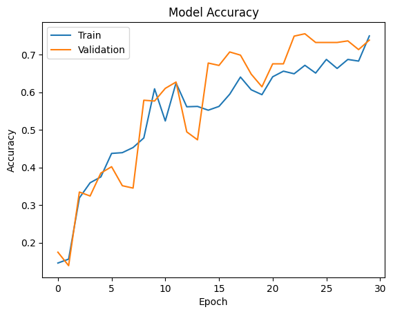

```python
#Plot the Training vs Validation Accuracy
plt.plot(history_B.history['accuracy'])
plt.plot(history_B.history['val_accuracy'])
plt.title('Model Accuracy')
plt.ylabel('Accuracy')
plt.xlabel('Epoch')
plt.legend(['Train', 'Validation'], loc='upper left')
plt.show()
```

**Evaluate the model on test data**

```python
# Evaluate the model on test data
accuracyB = modelB.evaluate(X_test_normalized, y_test_encoded, verbose=2)
```

```
15/15 - 0s - 6ms/step - accuracy: 0.7263 - loss: 0.8245
```

Observations:

- Max Test Accuracy is 73%
- An improvment from the base CNN model

**Plotting the Confusion Matrix**

```python
# Obtain the output probabilities
y_pred=modelB.predict(X_test_normalized)
```

```
15/15 ━━━━━━━━━━━━━━━━━━━━ 1s 30ms/step
```

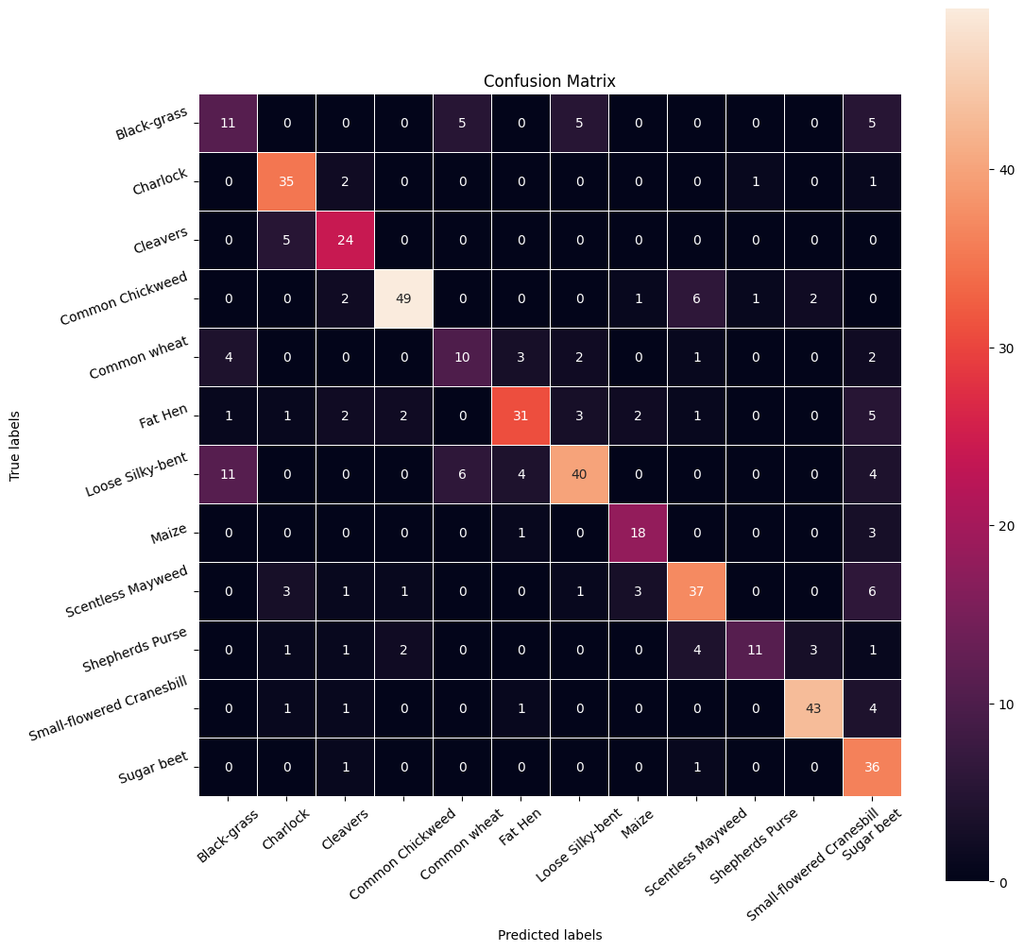

```python
# Obtaining the categorical values from y_test_encoded and y_pred
y_pred_arg=np.argmax(y_pred,axis=1)
y_test_arg=np.argmax(y_test_encoded,axis=1)

# Plotting the Confusion Matrix
confusion_matrix = tf.math.confusion_matrix(y_test_arg,y_pred_arg)
f, ax = plt.subplots(figsize=(12, 12))
sns.heatmap(
    confusion_matrix,
    annot=True,
    linewidths=.4,
    fmt="d",
    square=True,
    ax=ax
)
# Setting the labels to both the axes
ax.set_xlabel('Predicted labels');ax.set_ylabel('True labels');
ax.set_title('Confusion Matrix');
ax.xaxis.set_ticklabels(list(enc.classes_),rotation=40)
ax.yaxis.set_ticklabels(list(enc.classes_),rotation=20)
plt.show()
```

**Generating Classification Report**

```python
# Generating the classification report
crB = metrics.classification_report(y_test_arg,y_pred_arg)
print(crB)
```

```
              precision    recall  f1-score   support

           0       0.41      0.42      0.42        26
           1       0.76      0.90      0.82        39
           2       0.71      0.83      0.76        29
           3       0.91      0.80      0.85        61
           4       0.48      0.45      0.47        22
           5       0.78      0.65      0.70        48
           6       0.78      0.62      0.69        65
           7       0.75      0.82      0.78        22
           8       0.74      0.71      0.73        52
           9       0.85      0.48      0.61        23
          10       0.90      0.86      0.88        50
          11       0.54      0.95      0.69        38

    accuracy                           0.73       475
   macro avg       0.72      0.71      0.70       475
weighted avg       0.75      0.73      0.73       475
```

### Transfer Learning using VGG16

- Let's try again, but this time, we will be using the idea of **Transfer Learning**. We will be loading a pre-built architecture - **VGG16**, which was trained on the ImageNet dataset and is the runner-up in the ImageNet competition in 2014.
- For training VGG16, we will directly use the convolutional and pooling layers and freeze their weights i.e. no training will be done on them. For classification, we will replace the existing fully-connected layers with FC layers created specifically for our problem.

```python
# Clearing backend
backend.clear_session()

# Fixing the seed for random number generators
np.random.seed(13)
random.seed(13)
tf.random.set_seed(13)
```

```python
# Initialize VGG16 Transfer Learning Model
vgg_model = VGG16(weights='imagenet', include_top = False, input_shape = (64,64,3))
vgg_model.summary()
```

```
Model: "vgg16"
```

```
┏━━━━━━━━━━━━━━━━━━━━━━━━━━━━━━━━━━━━━━┳━━━━━━━━━━━━━━━━━━━━━━━━━━━━━┳━━━━━━━━━━━━━━━━━┓
┃ Layer (type)                         ┃ Output Shape                ┃         Param # ┃
┡━━━━━━━━━━━━━━━━━━━━━━━━━━━━━━━━━━━━━━╇━━━━━━━━━━━━━━━━━━━━━━━━━━━━━╇━━━━━━━━━━━━━━━━━┩
│ input_layer (InputLayer)             │ (None, 64, 64, 3)           │               0 │
├──────────────────────────────────────┼─────────────────────────────┼─────────────────┤
│ block1_conv1 (Conv2D)                │ (None, 64, 64, 64)          │           1,792 │
├──────────────────────────────────────┼─────────────────────────────┼─────────────────┤
│ block1_conv2 (Conv2D)                │ (None, 64, 64, 64)          │          36,928 │
├──────────────────────────────────────┼─────────────────────────────┼─────────────────┤
│ block1_pool (MaxPooling2D)           │ (None, 32, 32, 64)          │               0 │
├──────────────────────────────────────┼─────────────────────────────┼─────────────────┤
│ block2_conv1 (Conv2D)                │ (None, 32, 32, 128)         │          73,856 │
├──────────────────────────────────────┼─────────────────────────────┼─────────────────┤
│ block2_conv2 (Conv2D)                │ (None, 32, 32, 128)         │         147,584 │
├──────────────────────────────────────┼─────────────────────────────┼─────────────────┤
│ block2_pool (MaxPooling2D)           │ (None, 16, 16, 128)         │               0 │
├──────────────────────────────────────┼─────────────────────────────┼─────────────────┤
│ block3_conv1 (Conv2D)                │ (None, 16, 16, 256)         │         295,168 │
├──────────────────────────────────────┼─────────────────────────────┼─────────────────┤
│ block3_conv2 (Conv2D)                │ (None, 16, 16, 256)         │         590,080 │
├──────────────────────────────────────┼─────────────────────────────┼─────────────────┤
│ block3_conv3 (Conv2D)                │ (None, 16, 16, 256)         │         590,080 │
├──────────────────────────────────────┼─────────────────────────────┼─────────────────┤
│ block3_pool (MaxPooling2D)           │ (None, 8, 8, 256)           │               0 │
├──────────────────────────────────────┼─────────────────────────────┼─────────────────┤
│ block4_conv1 (Conv2D)                │ (None, 8, 8, 512)           │       1,180,160 │
├──────────────────────────────────────┼─────────────────────────────┼─────────────────┤
│ block4_conv2 (Conv2D)                │ (None, 8, 8, 512)           │       2,359,808 │
├──────────────────────────────────────┼─────────────────────────────┼─────────────────┤
│ block4_conv3 (Conv2D)                │ (None, 8, 8, 512)           │       2,359,808 │
├──────────────────────────────────────┼─────────────────────────────┼─────────────────┤
│ block4_pool (MaxPooling2D)           │ (None, 4, 4, 512)           │               0 │
├──────────────────────────────────────┼─────────────────────────────┼─────────────────┤
│ block5_conv1 (Conv2D)                │ (None, 4, 4, 512)           │       2,359,808 │
├──────────────────────────────────────┼─────────────────────────────┼─────────────────┤
│ block5_conv2 (Conv2D)                │ (None, 4, 4, 512)           │       2,359,808 │
├──────────────────────────────────────┼─────────────────────────────┼─────────────────┤
│ block5_conv3 (Conv2D)                │ (None, 4, 4, 512)           │       2,359,808 │
├──────────────────────────────────────┼─────────────────────────────┼─────────────────┤
│ block5_pool (MaxPooling2D)           │ (None, 2, 2, 512)           │               0 │
└──────────────────────────────────────┴─────────────────────────────┴─────────────────┘
```

```
 Total params: 14,714,688 (56.13 MB)
```

```
 Trainable params: 14,714,688 (56.13 MB)
```

```
 Non-trainable params: 0 (0.00 B)
```

```python
# Making all the layers of the VGG model non-trainable. i.e. freezing them
for layer in vgg_model.layers:
    layer.trainable = False
```

```python
# Intializing a sequential model
modelC = Sequential()

# Adding the convolutional part of the VGG16 model from above
modelC.add(vgg_model)

# Flattening the output of the VGG16 model because it is from a convolutional layer
modelC.add(Flatten())

# # Adding a dense output layer
modelC.add(Dense(32, activation='relu'))
# modelC.add(Dropout(0.3))
modelC.add(Dense(16, activation='relu'))
# modelC.add(Dropout(0.1))
modelC.add(Dense(12, activation='softmax'))
opt=Adam()
# Compile model
modelC.compile(optimizer=opt, loss='categorical_crossentropy', metrics=['accuracy'])

# Generating the summary of the model
modelC.summary()
```

```
Model: "sequential"
```

```
┏━━━━━━━━━━━━━━━━━━━━━━━━━━━━━━━━━━━━━━┳━━━━━━━━━━━━━━━━━━━━━━━━━━━━━┳━━━━━━━━━━━━━━━━━┓
┃ Layer (type)                         ┃ Output Shape                ┃         Param # ┃
┡━━━━━━━━━━━━━━━━━━━━━━━━━━━━━━━━━━━━━━╇━━━━━━━━━━━━━━━━━━━━━━━━━━━━━╇━━━━━━━━━━━━━━━━━┩
│ vgg16 (Functional)                   │ (None, 2, 2, 512)           │      14,714,688 │
├──────────────────────────────────────┼─────────────────────────────┼─────────────────┤
│ flatten (Flatten)                    │ (None, 2048)                │               0 │
├──────────────────────────────────────┼─────────────────────────────┼─────────────────┤
│ dense (Dense)                        │ (None, 32)                  │          65,568 │
├──────────────────────────────────────┼─────────────────────────────┼─────────────────┤
│ dense_1 (Dense)                      │ (None, 16)                  │             528 │
├──────────────────────────────────────┼─────────────────────────────┼─────────────────┤
│ dense_2 (Dense)                      │ (None, 12)                  │             204 │
└──────────────────────────────────────┴─────────────────────────────┴─────────────────┘
```

```
 Total params: 14,780,988 (56.38 MB)
```

```
 Trainable params: 66,300 (258.98 KB)
```

```
 Non-trainable params: 14,714,688 (56.13 MB)
```

```python
# Fit the model on train data with batch_size=64 and epochs=30
epochs = 30
batch_size = 64
# Fit the model on train data and also using the validation data for validation
history_C = modelC.fit(train_datagen.flow(X_train_normalized,y_train_encoded,
                                       batch_size=batch_size,
                                       seed=13,
                                       shuffle=False),
                                      epochs=epochs,
                    steps_per_epoch=X_train_normalized.shape[0] // batch_size,
                    validation_data=(X_val_normalized,y_val_encoded),
                    verbose=2)
```

```
59/59 - 12s - 199ms/step - accuracy: 0.2248 - loss: 2.3024 - val_accuracy: 0.2653 - val_loss: 2.1485
59/59 - 0s - 5ms/step - accuracy: 0.2344 - loss: 2.2081 - val_accuracy: 0.2716 - val_loss: 2.1466
59/59 - 5s - 92ms/step - accuracy: 0.3212 - loss: 2.0760 - val_accuracy: 0.3663 - val_loss: 1.9570
59/59 - 0s - 6ms/step - accuracy: 0.3594 - loss: 2.0192 - val_accuracy: 0.3621 - val_loss: 1.9507
59/59 - 12s - 199ms/step - accuracy: 0.3704 - loss: 1.9021 - val_accuracy: 0.3832 - val_loss: 1.7934
59/59 - 0s - 4ms/step - accuracy: 0.3281 - loss: 1.8288 - val_accuracy: 0.3811 - val_loss: 1.7862
59/59 - 5s - 91ms/step - accuracy: 0.4109 - loss: 1.7510 - val_accuracy: 0.4105 - val_loss: 1.6671
59/59 - 0s - 6ms/step - accuracy: 0.4531 - loss: 1.5761 - val_accuracy: 0.4253 - val_loss: 1.6673
59/59 - 10s - 168ms/step - accuracy: 0.4459 - loss: 1.6059 - val_accuracy: 0.4253 - val_loss: 1.5625
59/59 - 0s - 4ms/step - accuracy: 0.3750 - loss: 1.6891 - val_accuracy: 0.4189 - val_loss: 1.5709
59/59 - 15s - 252ms/step - accuracy: 0.4690 - loss: 1.5174 - val_accuracy: 0.4674 - val_loss: 1.5449
59/59 - 0s - 6ms/step - accuracy: 0.3750 - loss: 1.8294 - val_accuracy: 0.4842 - val_loss: 1.5230
59/59 - 11s - 194ms/step - accuracy: 0.5013 - loss: 1.4465 - val_accuracy: 0.4989 - val_loss: 1.4464
59/59 - 0s - 6ms/step - accuracy: 0.6406 - loss: 1.2969 - val_accuracy: 0.5011 - val_loss: 1.4582
59/59 - 5s - 90ms/step - accuracy: 0.5244 - loss: 1.3948 - val_accuracy: 0.4968 - val_loss: 1.4025
59/59 - 0s - 4ms/step - accuracy: 0.5156 - loss: 1.3957 - val_accuracy: 0.4968 - val_loss: 1.3906
59/59 - 7s - 122ms/step - accuracy: 0.5249 - loss: 1.3496 - val_accuracy: 0.5137 - val_loss: 1.4207
59/59 - 0s - 4ms/step - accuracy: 0.5625 - loss: 1.2948 - val_accuracy: 0.5200 - val_loss: 1.3953
59/59 - 8s - 136ms/step - accuracy: 0.5530 - loss: 1.3053 - val_accuracy: 0.5368 - val_loss: 1.3585
59/59 - 0s - 6ms/step - accuracy: 0.6094 - loss: 1.1606 - val_accuracy: 0.5411 - val_loss: 1.3418
59/59 - 7s - 114ms/step - accuracy: 0.5683 - loss: 1.2493 - val_accuracy: 0.5495 - val_loss: 1.2898
59/59 - 0s - 4ms/step - accuracy: 0.4688 - loss: 1.2377 - val_accuracy: 0.5453 - val_loss: 1.3011
59/59 - 5s - 88ms/step - accuracy: 0.5741 - loss: 1.2157 - val_accuracy: 0.5747 - val_loss: 1.2537
59/59 - 0s - 4ms/step - accuracy: 0.5156 - loss: 1.3277 - val_accuracy: 0.5747 - val_loss: 1.2590
59/59 - 10s - 172ms/step - accuracy: 0.5792 - loss: 1.2089 - val_accuracy: 0.5705 - val_loss: 1.2705
59/59 - 0s - 6ms/step - accuracy: 0.6562 - loss: 1.3337 - val_accuracy: 0.5832 - val_loss: 1.2659
59/59 - 6s - 105ms/step - accuracy: 0.5867 - loss: 1.1754 - val_accuracy: 0.5811 - val_loss: 1.2421
59/59 - 0s - 4ms/step - accuracy: 0.6406 - loss: 1.1248 - val_accuracy: 0.5853 - val_loss: 1.2439
59/59 - 6s - 97ms/step - accuracy: 0.5899 - loss: 1.1679 - val_accuracy: 0.5474 - val_loss: 1.3054
59/59 - 0s - 4ms/step - accuracy: 0.5312 - loss: 1.2959 - val_accuracy: 0.5726 - val_loss: 1.2722
```

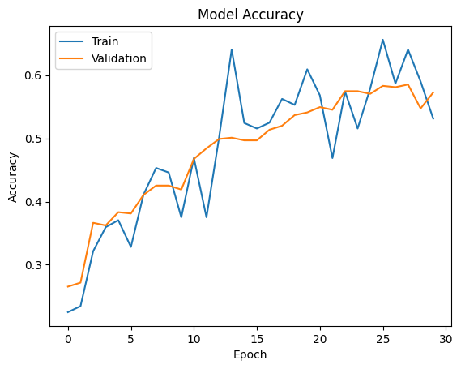

```python
#Plot the Training vs Validation Accuracy
plt.plot(history_C.history['accuracy'])
plt.plot(history_C.history['val_accuracy'])
plt.title('Model Accuracy')
plt.ylabel('Accuracy')
plt.xlabel('Epoch')
plt.legend(['Train', 'Validation'], loc='upper left')
plt.show()
```

Observations:

- The transfer learning (VGG16) model actually had a worse accuracy than the Data Augumented model; the difference between fluctuated throughout
- The training accuracy is 53%
- The validation accruacy is 57%

```python
# Evaluate the model on test data
accuracyC = modelC.evaluate(X_test_normalized, y_test_encoded, verbose=2)
```

```
15/15 - 0s - 18ms/step - accuracy: 0.5368 - loss: 1.3352
```

Observations:

- The max test accuracy seen is ~55%

```python
# Here we would get the output as probablities for each category
y_pred=modelC.predict(X_test_normalized)
```

```
15/15 ━━━━━━━━━━━━━━━━━━━━ 1s 51ms/step
```

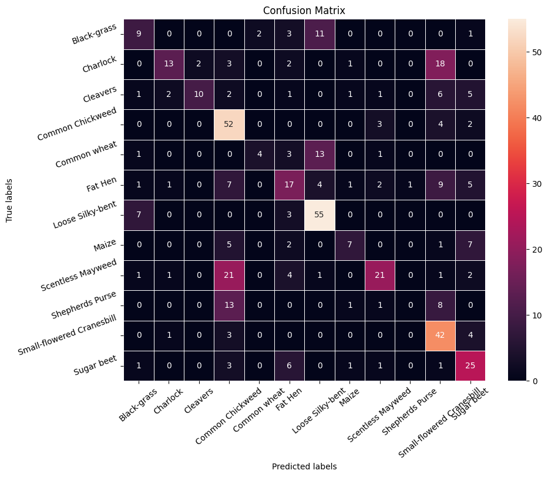

```python
# Obtaining the categorical values from y_test_encoded and y_pred
y_pred_arg=np.argmax(y_pred,axis=1)
y_test_arg=np.argmax(y_test_encoded,axis=1)

# Plotting the Confusion Matrix
confusion_matrix = tf.math.confusion_matrix(y_test_arg,y_pred_arg)
f, ax = plt.subplots(figsize=(10, 8))
sns.heatmap(
    confusion_matrix,
    annot=True,
    linewidths=.4,
    fmt="d",
    square=True,
    ax=ax
)

# Setting the labels to both the axes
ax.set_xlabel('Predicted labels');ax.set_ylabel('True labels');
ax.set_title('Confusion Matrix');
ax.xaxis.set_ticklabels(list(enc.classes_),rotation=40)
ax.yaxis.set_ticklabels(list(enc.classes_),rotation=20)
plt.show()
```

**Generating Classification Report**

```python
# Generating the classification report
crC=metrics.classification_report(y_test_arg,y_pred_arg)
print(crC)
```

```
              precision    recall  f1-score   support

           0       0.43      0.35      0.38        26
           1       0.72      0.33      0.46        39
           2       0.83      0.34      0.49        29
           3       0.48      0.85      0.61        61
           4       0.67      0.18      0.29        22
           5       0.41      0.35      0.38        48
           6       0.65      0.85      0.74        65
           7       0.58      0.32      0.41        22
           8       0.70      0.40      0.51        52
           9       0.00      0.00      0.00        23
          10       0.47      0.84      0.60        50
          11       0.49      0.66      0.56        38

    accuracy                           0.54       475
   macro avg       0.54      0.46      0.45       475
weighted avg       0.55      0.54      0.50       475
```

Observations:

## Final Model

Comment on the final model you have selected and use the same in the below code to visualize the image.

```python
#Performance Metrics
pd.DataFrame({'Models':['Base CNN Model','CNN Model with Data Augmentation','Transfer Learning Model (VGG16)'],'Train Accuracy':['55%','75%','53%'],'Validation Accuracy':['69%','74%','57%'],'Test Accuracy':['65%','73%','54%']})
```

|  | Models | Train Accuracy | Validation Accuracy | Test Accuracy |
| --- | --- | --- | --- | --- |
| 0 | Base CNN Model | 55% | 69% | 65% |
| 1 | CNN Model with Data Augmentation | 75% | 74% | 73% |
| 2 | Transfer Learning Model (VGG16) | 53% | 57% | 54% |

**Model Chosen:**

- **ModelB or the Data Augmented CNN model was ultimately chosen** as it had the best model performance across the board

### Visualizing the prediction

[figure not shown]

```
1/1 ━━━━━━━━━━━━━━━━━━━━ 0s 17ms/step
Predicted Label ['Common Chickweed']
True Label Black-grass
```

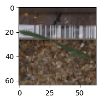

```
1/1 ━━━━━━━━━━━━━━━━━━━━ 0s 16ms/step
Predicted Label ['Small-flowered Cranesbill']
True Label Common wheat
```

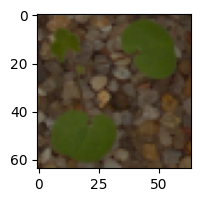

```
1/1 ━━━━━━━━━━━━━━━━━━━━ 0s 16ms/step
Predicted Label ['Small-flowered Cranesbill']
True Label Small-flowered Cranesbill
```

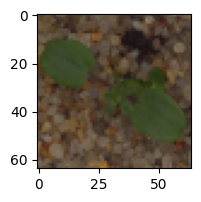

```
1/1 ━━━━━━━━━━━━━━━━━━━━ 0s 16ms/step
Predicted Label ['Cleavers']
True Label Cleavers
```

```python
# Visualizing the predicted and correct label of images from test data
plt.figure(figsize=(2,2))
plt.imshow(X_test[16])
plt.show()
## Predict the test data using the final model selected
print('Predicted Label', enc.inverse_transform(modelB.predict(X_test_normalized[2].reshape(1,64,64,3))))   # reshaping the input image as we are only trying to predict using a single image
print('True Label', enc.inverse_transform(y_test_encoded)[16])                                               # using inverse_transform() to get the output label from the output vector

plt.figure(figsize=(2,2))
plt.imshow(X_test[32])
plt.show()
## Predict the test data using the final model selected
print('Predicted Label', enc.inverse_transform(modelB.predict(X_test_normalized[33].reshape(1,64,64,3))))  # reshaping the input image as we are only trying to predict using a single image
print('True Label', enc.inverse_transform(y_test_encoded)[32])                                              # using inverse_transform() to get the output label from the output vector

plt.figure(figsize=(2,2))
plt.imshow(X_test[48])
plt.show()
## Predict the test data using the final model selected
print('Predicted Label', enc.inverse_transform(modelB.predict(X_test_normalized[48].reshape(1,64,64,3))))  # reshaping the input image as we are only trying to predict using a single image
print('True Label', enc.inverse_transform(y_test_encoded)[48])                                              # using inverse_transform() to get the output label from the output vector

plt.figure(figsize=(2,2))
plt.imshow(X_test[64],)
plt.show()
## Predict the test data using the final model selected
print('Predicted Label', enc.inverse_transform(modelB.predict((X_test_normalized[64].reshape(1,64,64,3)))))  # reshaping the input image as we are only trying to predict using a single image
print('True Label', enc.inverse_transform(y_test_encoded)[64])                                              # using inverse_transform() to get the output label from the output vector
```

## Actionable Insights and Business Recommendations

**Conclusions/Insights:**

- It can be observed via the confusion matrix and across the accuracy scores recorded that modelB/ the Data Augmented Model is the best model of the three created in identifiying the plant classes in images of the dataset
- A majority of the plant classes were able to be identified reasonably well
- Plant classes such as Black Grass and Common Wheat will need further training and model tuning

# Convert to HTML

```python
!pip install nbconvert
```

```python
!jupyter nbconvert --to html '/content/drive/My Drive/ColabNotebooks/CV_Project_Full_Code_JRWNotebook.ipynb'
```